# Group Project

Alex, Christopher, Helen, Yunze

```r
library(tidyverse)
library(fivethirtyeight)
library(dplyr)
library(moderndive)
library(broom)
```

# Description of Data

steak_survey_2 is a survey of 432 steak eaters in the US. It originally came from a surveymonkey audience poll, an online polling company.

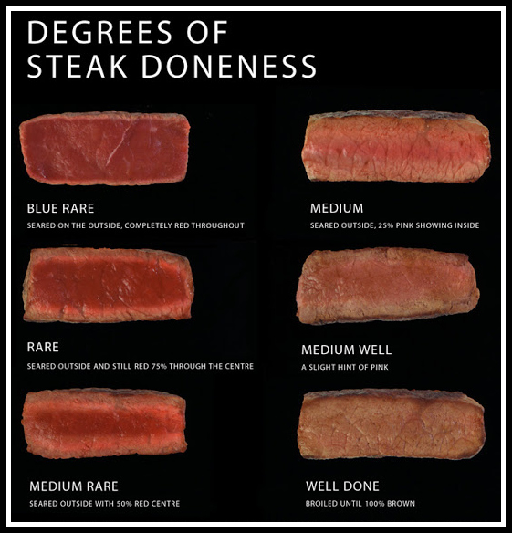

steak chart!

### Why this data?

In this data, we are going to be looking for influences that lead to type of steak consumed.

- Relationship between demographics and food consumption?
- Is the type of steak consumed associated with a higher status than others?
- Mix of geography and sociology research

Research Question: what factor impacts the types of steaks people consume?

Response variable: steak_prep

Predictive variables: Region of US, Household Income, Age

### Hypothesis

- Region of US: Midwestern states more likely to consume rare steak due to high steak production and exposure to different cooking styles
- Household Income: Wealthier people more likely to consume rare steak because it’s seen as a status symbol.
- Age: Older People more likely to conume rare compared to younger people due to maturity.

# Exploratory Graphs and Overview of Data:

The following graph gives an overview of how many people eat each type of steak in the US.

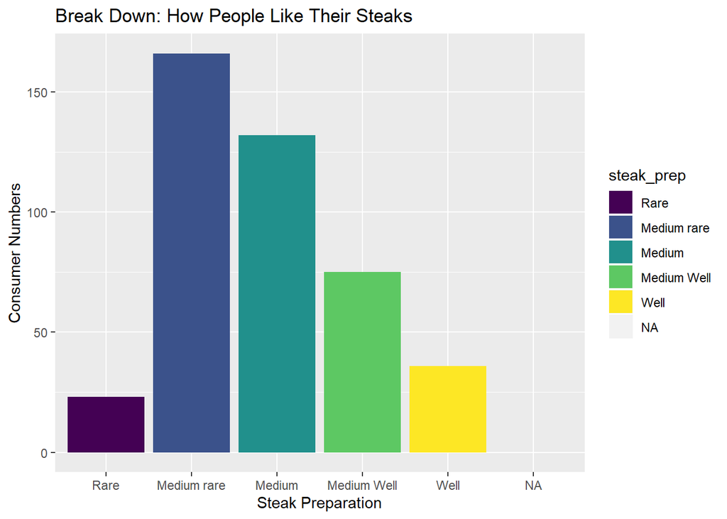

Because all the variables we are looking at are categorical, we decided to adjust the data and divide them into two categories, as we intend to run logistic regressions later on. Rare and Medium rare are grouped together as “Relatively Rare”, and the rest is grouped together as “Not Rare”

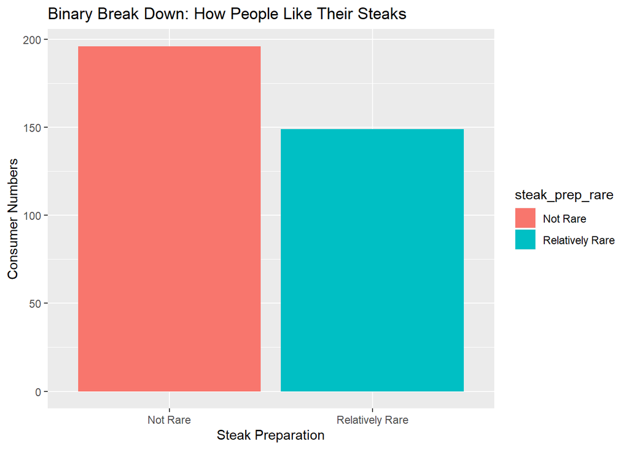

#### Region

This graph shows the types of steaks consumed by location. From these graphs, there are some notable variations between regions. Some regions have more people consuming rare and medium rare steaks, including East Souch Central, New England, West North Central and West Souch Central.

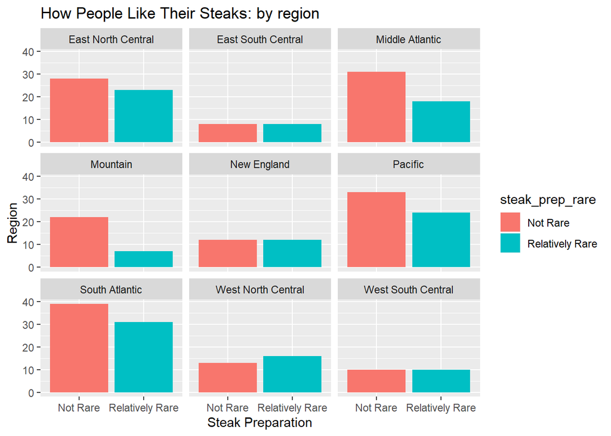

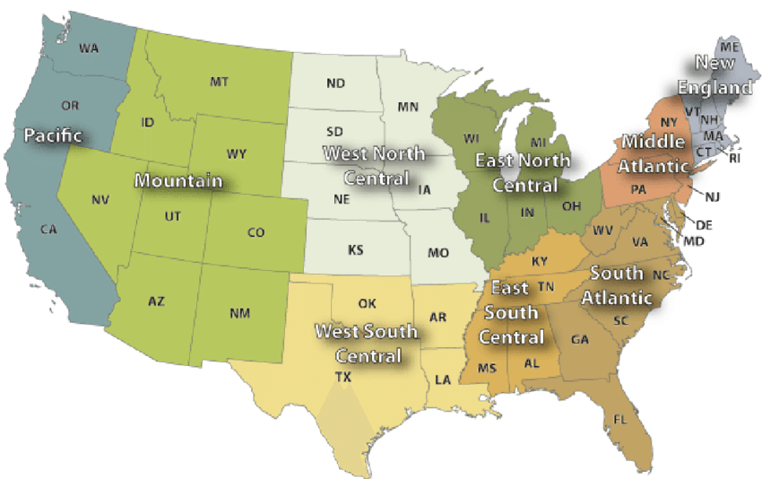

U.S. Census Regions

#### Income

The following graph shows the relationship between type of steak and income. There isn’t a super clear pattern here. Almost all income brackets prefer medium-welldone over rare and medium-rare. However, the differences seem less notable between two income groups: $25,000 - $49,999 and $100,000 - $149,999

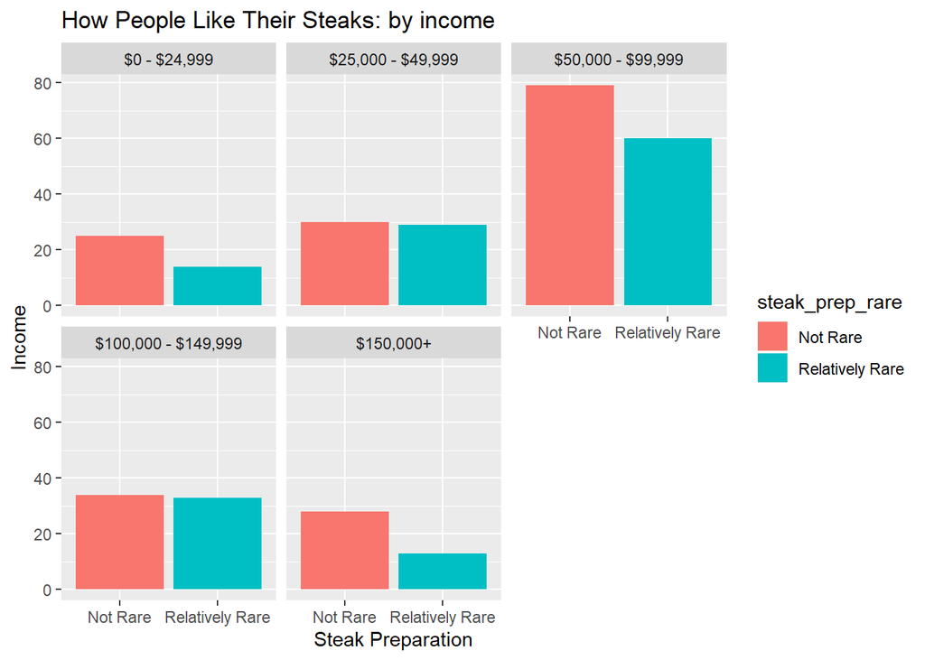

#### Age

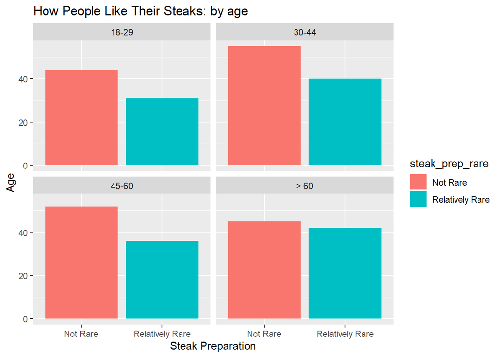

# Initial Modeling

We constructed one-variable logistic models with all three variables, and we mutated the data so we can see the odds with the variables. Here we set “not rare” as 0, and “relatively rare” as 1. In other words, in all these models the odds are interpreted as the odds for liking relatively rare steaks.

$$Odds(X) = e^{\beta_0}e^{\beta_1 x_1} e^{\beta_2 x_2} . . . e^{\beta_k x_k}$$

**Model based on age:**

| term | estimate | exp_est |
| --- | --- | --- |
| (Intercept) | -0.35020243 | 0.7045455 |
| age30-44 | 0.03174870 | 1.0322581 |
| age45-60 | -0.01752235 | 0.9826303 |
| age> 60 | 0.28120956 | 1.3247312 |

From this model, the predicted odds that a person below age 30 prefers rare steak is $e^{-0.35020243}=0.7045$, or a probability of about 41.3%. These odds remain essentially the same for ages 30 - 60, but for people older than 60, they are multiplied by 1.32. Overall, this model shows little effect of age on steak preference, except that people older than 60 are slightly more likely to prefer rare steak.

**Model based on income:**

| term | estimate | exp_est |
| --- | --- | --- |
| (Intercept) | -0.5798185 | 0.5600000 |
| hhold_income$25,000 - $49,999 | 0.5459169 | 1.7261905 |
| hhold_income$50,000 - $99,999 | 0.3047152 | 1.3562387 |
| hhold_income$100,000 - $149,999 | 0.5499655 | 1.7331933 |
| hhold_income$150,000+ | -0.1874367 | 0.8290816 |

From this model, the predicted odds that a person with income below $25,000 prefers rare steak is $e^{-0.5798185}=0.56$, or a probability of about 35.9%. These odds are multiplied by approximately 1.73 for both the $25,000-49,999 and 100,000-149,999 income brackets. However, for those with incomes over $150,000, the odds are decreased by a factor of 0.829. This indicates that the wealthiest people are actually less likely to prefer rare steak than the least wealthy.

**Model based on region:**

| term | estimate | exp_est |
| --- | --- | --- |
| (Intercept) | -0.19671029 | 0.8214286 |
| regionEast South Central | 0.19671029 | 1.2173913 |
| regionMiddle Atlantic | -0.34690515 | 0.7068724 |
| regionMountain | -0.94842201 | 0.3873518 |
| regionNew England | 0.19671029 | 1.2173913 |
| regionPacific | -0.12174344 | 0.8853755 |
| regionSouth Atlantic | -0.03286415 | 0.9676700 |
| regionWest North Central | 0.40434966 | 1.4983278 |
| regionWest South Central | 0.19671029 | 1.2173913 |

##### We can conclude three different findings:

1. The odds of people liking rare or medium rare steaks is about the same for all age groups, except people above 60 who are slightly more likely to prefer it;
2. There does not seem to be a consistent relationship between income and how people like their steaks;
3. And finally, East South Central, West North Central, New England, and West South Central seem to have higher odds of liking rare steaks. With the exception of New England, All these regions are in the middle of the country. Perhaps this means that people living in the middle of the U.S. prefer rare steaks more than the rest of the country.

# Modeling Test

In order to understand how strong these models are for further analysis, we will try to do hypothesis testing for all three of them. The null hypothesis is that each of three predictive variables (age, income, region) will not have an impact on the response variable (steak preparation). The alternative hypothesis is that there are impacts. Since all three models use only categorical variables, we will run ANOVA tests for hypothesis testing.

To do so, we first constructed a null model with no predictive variable.

| term | estimate | exp_est |
| --- | --- | --- |
| (Intercept) | -0.2741684 | 0.7602041 |

Then we use ANOVA to compare the null model to all three models:

**Age Model:**

| Resid..Df | Resid..Dev | df | Deviance | p.value |
| --- | --- | --- | --- | --- |
| 344 | 471.8487 | NA | NA | NA |
| 341 | 470.5996 | 3 | 1.249067 | 0.7412616 |

**Income Model:**

| Resid..Df | Resid..Dev | df | Deviance | p.value |
| --- | --- | --- | --- | --- |
| 344 | 471.8487 | NA | NA | NA |
| 340 | 466.8720 | 4 | 4.976658 | 0.289701 |

**Region Model:**

| Resid..Df | Resid..Dev | df | Deviance | p.value |
| --- | --- | --- | --- | --- |
| 344 | 471.8487 | NA | NA | NA |
| 336 | 463.4878 | 8 | 8.360949 | 0.3990289 |

Unfortunately, all three models we have explored have overwhelmingly high p-values. Thus we can not reject any of the null hypotheses. Even though there were some indicators (both region and age) of the steak preferences of people, we can not affirm the relationship.

# Conclusion

- Original Question: what factor impacts the types of steaks people consume?
- The answer: We don’t know :( Sometimes Stats is like that!
- Graphs Overview:
  - 1. Age: older people eat proportionately more rare steak
  - 2. Income: No real pattern
  - 3. Region: Central states appear to like rare steak
- Calculations: The p-values all came back very high We can’t reject our null hypothesis!

[figure not shown]

bessy!